## Introducción

El presente informe tiene como objetivo analizar un conjunto de datos correspondiente al famoso dataset **KDD Cup 1999**, ampliamente utilizado en el campo de la detección de intrusiones en redes informáticas. Este dataset contiene una gran cantidad de registros que representan conexiones de red, clasificadas como normales o como diferentes tipos de ataques.

### Problema

En entornos informáticos, la identificación automática de patrones anómalos en el tráfico de red es crucial para la seguridad. Los sistemas de detección de intrusos (IDS) buscan automatizar esta tarea, y para ello necesitan datos fiables y bien estructurados. Comprender cómo se distribuyen y relacionan las variables del dataset KDD Cup permite sentar las bases para construir modelos predictivos eficientes.

### Objetivos del análisis

- Explorar y limpiar los datos del archivo `kddcup_cleaned.csv`.
- Visualizar y analizar la distribución de variables clave según la clase de conexión.
- Identificar relaciones entre variables numéricas que puedan ser útiles en tareas de clasificación.
- Documentar el proceso de análisis con código bien comentado para facilitar su comprensión y reproducibilidad.

Este informe se generará en formato HTML utilizando RMarkdown.

## Exploración y limpieza de datos

Antes de realizar cualquier análisis o visualización, es fundamental asegurarse de que los datos estén limpios y correctamente estructurados. Para ello, se siguieron los siguientes pasos:

1. **Carga del dataset**: Se importó el archivo `kddcup_cleaned.csv` desde su ubicación local utilizando `read.csv()`.
2. **Exploración inicial**: Se utilizaron funciones como `summary()`, `str()` y `head()` para obtener una visión general de los tipos de datos, su estructura y valores extremos.
3. **Manejo de valores faltantes**: Se identificaron y eliminaron las filas con valores perdidos (`NA`) utilizando la función `na.omit()`. Esto garantiza que el análisis posterior no se vea afectado por datos incompletos.
4. **Conversión de tipos de variables**: Algunas columnas se convirtieron a factores (por ejemplo, `V2`, `V3`, `V4`, `V70`) y otras a numéricas (`V5`, `V6`, `V8`), para asegurar su tratamiento adecuado en los análisis estadísticos y gráficos.
5. **Creación de nueva variable**: Se creó una nueva variable llamada `promedio_valores`, que representa el promedio de las columnas `V5`, `V6` y `V8`. Esta variable resume de forma sencilla una combinación de tres métricas numéricas.
6. **Cálculo de estadísticas descriptivas agrupadas**: Se agruparon los datos por la clase (`V70`) y se calcularon promedios y medianas para las variables numéricas seleccionadas.

Estas transformaciones prepararon los datos para su análisis y facilitaron la generación de gráficos representativos.

## Visualización y análisis

Una vez que los datos fueron limpiados y preparados, se procedió a generar diversas visualizaciones para explorar las distribuciones y relaciones entre variables. A continuación, se destacan algunas de las más relevantes:

### Gráfico 1: Distribución de V5 según clase (`V70`)

Se utilizó un diagrama de cajas (*boxplot*) para observar cómo varían los valores de la variable `V5` en función de la clase (`V70`).

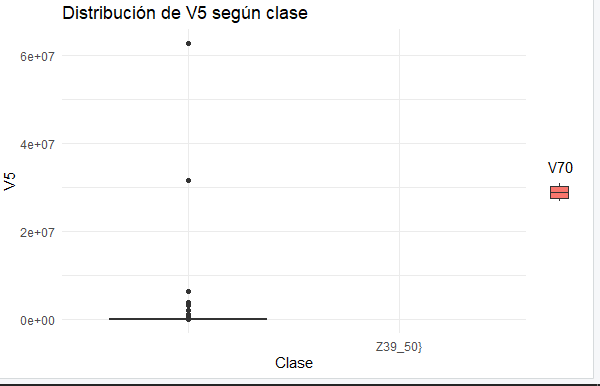

### Gráfico 2: Dispersión entre V5 y V6

Se elaboró un gráfico de dispersión coloreado por clase para analizar la relación entre las variables `V5` y `V6`.

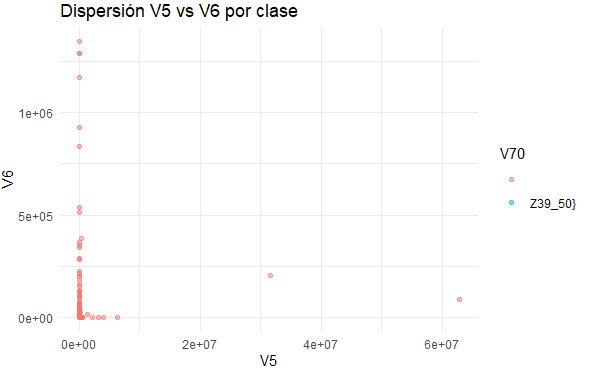

Dispersión V5 vs V6 por clase